# Mesure de la biodiversité dans le cadre de la théorie de l’information

12 juin 2024

## Motivation

## Facettes de la biodiversité

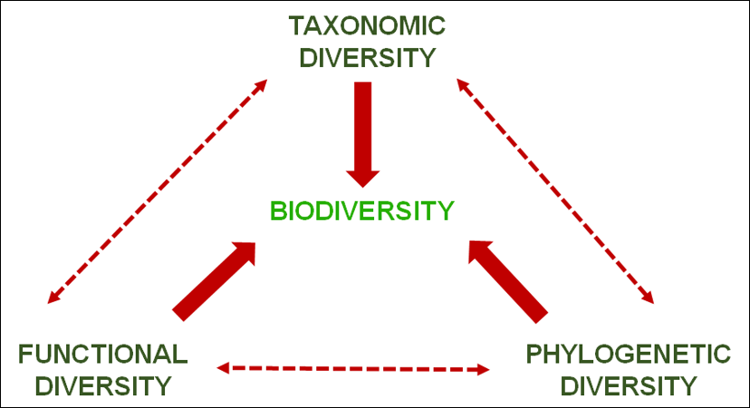

Figure de Swenson (2011). Dépasser la seule richesse spécifique.

## Diversité taxonomique

## Formalisation

On connaît la probabilité qu’un individu appartienne à une espèce particulière : \(p_s\).

L’information \(I(p_s)\) est la surprise apportée par l’observation de l’espèce \(s\). Elle est strictement décroissante et \(I(1)=0\).

L’entropie est l’espérance de l’information apportée par une observation (Maasoumi 1993).

## Entropie de Shannon

L’inverse de la probabilité \(p_s\) est appelé *rareté* de l’espèce \(s\)

L’information de Shannon est \(\ln(1/p_s)\)

\(\implies\) L’information de Shannon est le logarithme de la rareté.

L’entropie de Shannon (1948) est la moyenne de l’information apportée par tous les individus :

\[ H = \sum^S_{s=1}{p_s\log{\frac{1}{p_s}}} \]

## Généralisation

Modification de la fonction d’information : logarithme déformé d’ordre \(q\) (Tsallis 1994) : \(\ln_q x = \frac{x^{1-q} -1}{1-q}\)

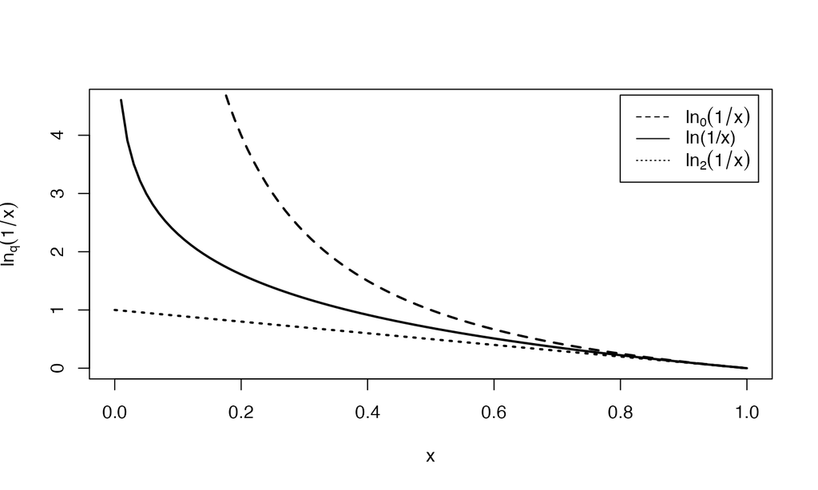

## Entropie HCDT

L’entropie HCDT (Havrda and Charvát 1967; Daróczy 1970; Tsallis 1988) d’ordre q est la moyenne du logarithme déformé de la rareté :

\[^{q}H = \sum_s{p_s ln_q{(1/p_s)}}\]

Elle généralise les mesures traditionnelles :

- \(^{0}H\) est le nombre d’espèces moins 1
- \(^{1}H\) est l’indice de Shannon
- \(^{2}H\) est l’indice de Simpson

Elle permet de choisir l’importance des espèces rares.

## Nombres de Hill

Hurlbert (1971) publie *The Nonconcept of Species Diversity: A Critique and Alternative Parameters* : l’entropie est peu intuitive.

Hill (1973) introduit les nombres effectifs (devenus Nombres de Hill) :

- nombres d’espèces équiprobables ayant la même entropie que les données (concept de Wright 1931)

## Nombres de Hill

Le nombres de Hill d’ordre \(q\) est l’exponentielle déformée de l’entropie (Marcon et al. 2014) : \[e^x_q = [1 + (1 - q)x]^{\frac{1}{1-q}}.\]

C’est la définition de la diversité au sens strict (Jost 2006)

\[^{q}D = e_q^{^{q}H}\]

C’est un *nombre effectif* d’espèces (Gregorius 1991).

## Profils de Diversité

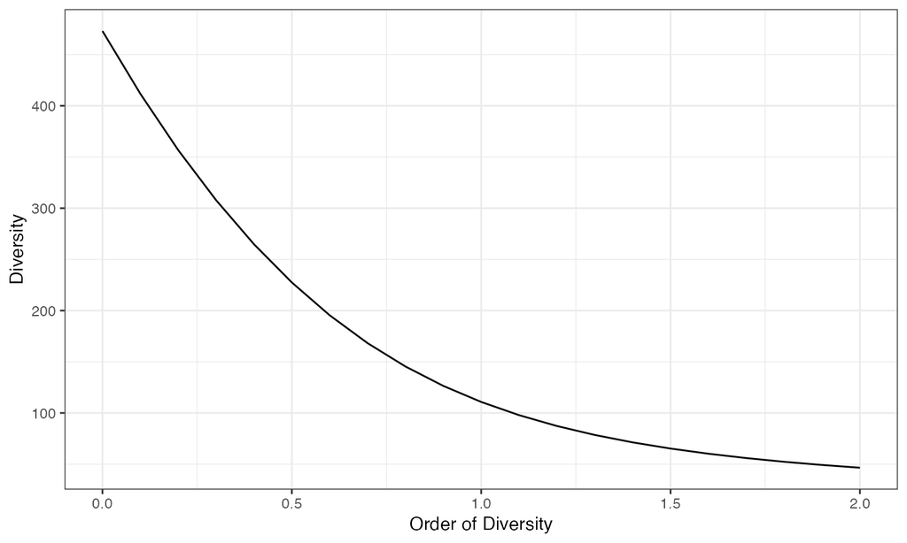

Profils de diversité des arbres de la parcelle 6 de Paracou

## Extensions

## Diversité phylogénétique

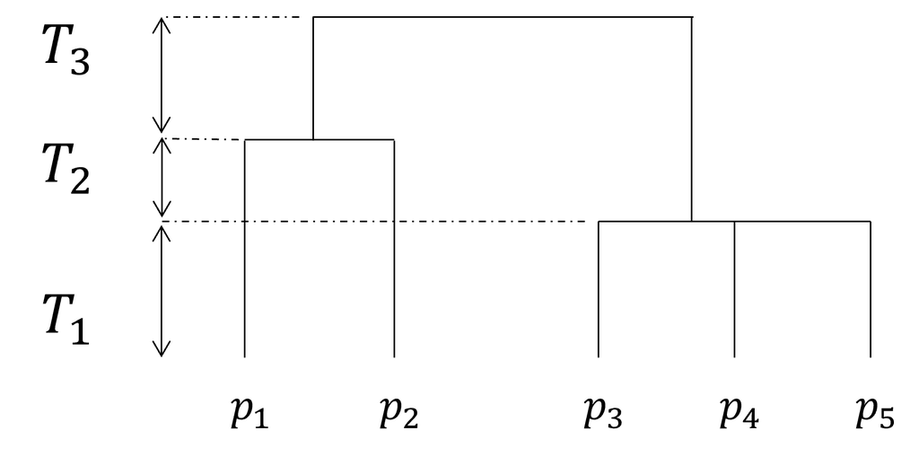

L’entropie est calculée à chaque période de l’arbre, et moyennée.

La diversité est son exponentielle (Marcon and Hérault 2015a).

## Diversité fonctionnelle

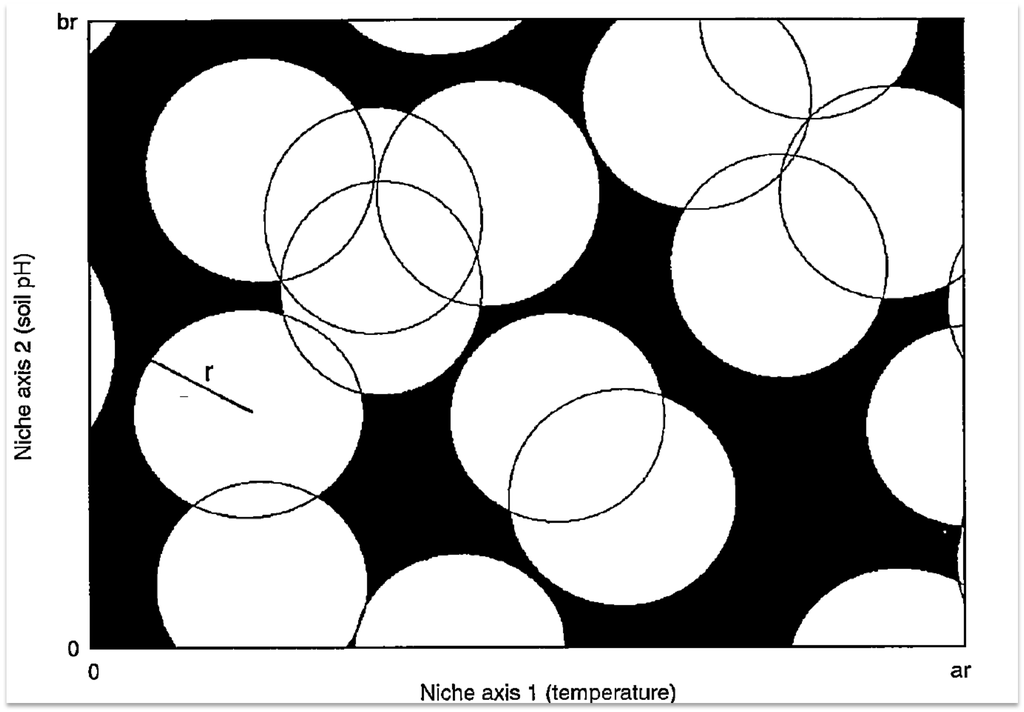

Figure de Tilman (2001). La similarité entre espèces définit à quel point deux espèces sont fonctionnellement proches : nécessite de définir une matrice de similarité \(\mathbf{Z}\).

## Diversité fonctionnelle

La banalité d’une espèce est la similarité moyenne de ses représentants avec les autres individus (Leinster and Cobbold 2012) : \(\mathbf{Zp}\)

La rareté est l’inverse de la banalité : \(1/\mathbf{Zp}_s\)

Le reste des définitions est inchangé.

## Estimation

## Accumulation

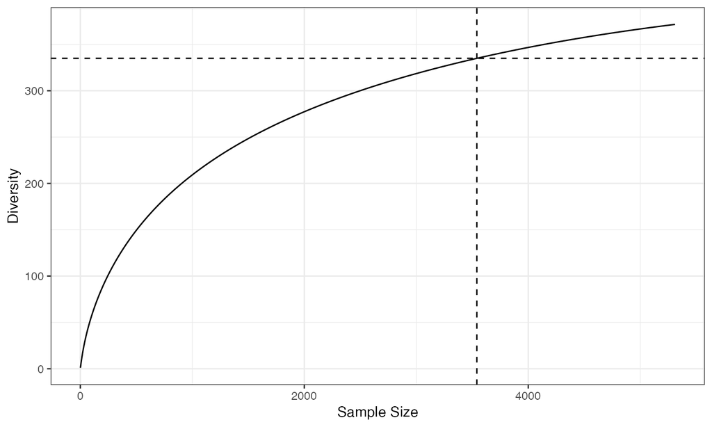

Raréfaction exacte, extrapolation estimée.

## Diversité asymptotique

Diversité de la communauté entière, dont on aurait inventorié tous les individus.

En forêt tropicale : convention.

Diversité asymptotique estimée de Paracou, parcelle 6 : 473 espèces.

## Conclusion

## Avantages

Théorie complète et robuste pour unifier la mesure de la biodiversité d’un taxon ou d’un groupe biologique (les arbres).

Mémorisation simple :

- l’information est le logarithme de la rareté,
- l’entropie est l’espérance de l’information,
- la diversité est l’exponentielle de l’entropie.

Synthèse : https://github.com/EricMarcon/MesuresBioDiv2

Outils mathématiques (estimateurs) disponibles dans deux package R : *entropart* (Marcon and Hérault 2015b) et iNEXT.3D (Chao et al. 2021).

## Limites

Ne prend en compte qu’un groupe biologique.

Pas de théorie sur la composition des mesures (ex.: diversité des arbres et des papillons)

Nécessite beaucoup de données, peu utilisable à grande échelle.

## References

Chao, Anne, Peter A. Henderson, Chun-Huo Chiu, Faye Moyes, Kai-Hsiang Hu, Maria Dornelas, and Anne E. Magurran. 2021. “Measuring Temporal Change in Alpha Diversity: A Framework Integrating Taxonomic, Phylogenetic and Functional Diversity and the iNEXT . 3D Standardization.” *Methods in Ecology and Evolution* 12 (10): 1926–40. https://doi.org/10.1111/2041-210X.13682.

Daróczy, Zoltán. 1970. “ Generalized information functions.” *Information and Control* 16 (1): 36–51. https://doi.org/10.1016/s0019-9958(70)80040-7.

Gregorius, Hans-Rolf. 1991. “ On the concept of effective number.” *Theoretical Population Biology* 40 (2): 269–83. http://www.ncbi.nlm.nih.gov/pubmed/1788824.

Havrda, Jan, and František Charvát. 1967. “ Quantification method of classification processes. Concept of structural alpha-entropy.” *Kybernetika* 3 (1): 30–35. https://eudml.org/doc/28681.

Hill, M. O. 1973. “ Diversity and Evenness: A Unifying Notation and Its Consequences.” *Ecology* 54 (2): 427–32. https://doi.org/10.2307/1934352.

Hurlbert, Stuart H. 1971. “ The Nonconcept of Species Diversity: A Critique and Alternative Parameters.” *Ecology* 52 (4): 577–86. https://doi.org/10.2307/1934145.

Jost, Lou. 2006. “ Entropy and diversity.” *Oikos* 113 (2): 363–75. https://doi.org/10.1111/j.2006.0030-1299.14714.x.

Leinster, Tom, and Christina Cobbold. 2012. “Measuring Diversity: The Importance of Species Similarity.” *Ecology* 93 (3): 477–89. https://doi.org/10.1890/10-2402.1.

Maasoumi, Esfandiar. 1993. “A Compendium to Information Theory in Economics and Econometrics.” *Econometric Reviews* 12 (2): 137–81. https://doi.org/10.1080/07474939308800260.

Marcon, Eric, and Bruno Hérault. 2015a. “ Decomposing Phylodiversity.” *Methods in Ecology and Evolution* 6 (3): 333–39. https://doi.org/10.1111/2041-210X.12323.

———. 2015b. “ entropart, an R Package to Measure and Partition Diversity.” *Journal of Statistical Software* 67 (8): 1–26. https://doi.org/10.18637/jss.v067.i08.

Marcon, Eric, Ivan Scotti, Bruno Hérault, Vivien Rossi, and Gabriel Lang. 2014. “ Generalization of the Partitioning of Shannon Diversity.” *Plos One* 9 (3): e90289. https://doi.org/10.1371/journal.pone.0090289.

Shannon, Claude E. 1948. “ A Mathematical Theory of Communication.” *The Bell System Technical Journal* 27: 379–423, 623–56.

Swenson, Nathan G. 2011. “The Role of Evolutionary Processes in Producing Biodiversity Patterns, and the Interrelationships Between Taxonomic, Functional and Phylogenetic Biodiversity.” *American Journal of Botany* 98 (3): 472–80. https://doi.org/10.3732/ajb.1000289.

Tilman, David. 2001. “Functional Diversity.” In *Encyclopedia of Biodiversity*, edited by Simon Levin, 109–21. San Diego: Academic Press.

Tsallis, Constantino. 1988. “ Possible generalization of Boltzmann-Gibbs statistics.” *Journal of Statistical Physics* 52 (1): 479–87. https://doi.org/10.1007/BF01016429.

———. 1994. “ What are the numbers that experiments provide?” *Qu ímica Nova* 17 (6): 468–71. http://quimicanova.sbq.org.br/detalhe{\_}artigo.asp?id=5517.

Wright, Sewall. 1931. “ Evolution in Mendelian Populations.” *Genetics* 16 (2): 97–159.